# CDS 101 – Example EDA Walkthrough (Rubric-Aligned)

November 20, 2025

# 1 1. Introduction (Context for Problem Definition)

This mini notebook demonstrates a simple **Exploratory Data Analysis (EDA)** workflow using a small sample dataset.

Rubric connections:

- Helps with **Problem Definition** by clarifying what variables exist.
- Directly supports the **EDA** and **Visualization Quality** criteria.

We will:

- Load a sample dataset (`data/sample_data.csv`)
- Compute basic summary statistics
- Create several example plots:
  - Histogram
  - Boxplot
  - Scatter plot
- Add short interpretations that explicitly connect visuals to potential research questions.

# 2 2. Load the Data (Data Acquisition & Description)

This chunk illustrates how to **load** and **inspect** your data, covering the **Data Acquisition & Description** rubric criterion.

```r
data <- read.csv("../data/sample_data.csv")
str(data)
```

```
## 'data.frame':    100 obs. of  3 variables:
##  $ x    : num  55 48.6 56.5 65.2 47.7 ...
##  $ y    : num  108.2 82.4 135.2 122 108.7 ...
##  $ group: chr  "A" "B" "A" "A" ...
```

```r
head(data)
```

```
##          x         y group
## 1 54.96714 108.18548     A
## 2 48.61736  82.40379     B
## 3 56.47689 135.15653     A
## 4 65.23030 121.99763     A
## 5 47.65847 108.72883     A
## 6 47.65863 104.92440     B
```

The columns are:

- `x`: a numeric variable (e.g., some measurement)
- `y`: another numeric variable related to `x`
- `group`: a categorical variable with two groups (A and B)

Here you would describe, in your own project:

- Where the data came from (source/link)
- What each variable represents
- How many rows and columns you have

# 3 3. Summary Statistics (EDA – Numeric Summaries)

This section contributes to the **EDA** rubric by showing numeric summaries.

```r
summary(data)
```

```
##        x               y             group
##  Min.   :23.80   Min.   : 46.17   Length:100
##  1st Qu.:43.99   1st Qu.: 79.47   Class :character
##  Median :48.73   Median : 97.24   Mode  :character
##  Mean   :48.96   Mean   : 99.22
##  3rd Qu.:54.06   3rd Qu.:118.59
##  Max.   :68.52   Max.   :199.08
```

```r
data %>%
  group_by(group) %>%
  summarise(
    mean_x = mean(x),
    sd_x   = sd(x),
    mean_y = mean(y),
    sd_y   = sd(y),
    .groups = "drop"
  )
```

```
## # A tibble: 2 × 5
##   group mean_x  sd_x mean_y  sd_y
##   <chr>  <dbl> <dbl>  <dbl> <dbl>
## 1 A       49.7  9.13  114.   25.3
## 2 B       48.3  9.07   85.7  23.3
```

**How this satisfies the EDA rubric:**

- We report descriptive statistics (mean, sd, etc.).
- We compare groups A and B, which could relate to a research question like:

> “Do groups A and B differ in their average values of `x` and `y`?”

# 4 4. Histogram of `x` (EDA + Visualization Quality)

This plot addresses both **EDA** and **Visualization Quality**:

- It reveals the distribution of `x`.
- It uses appropriate labels and a clear title.

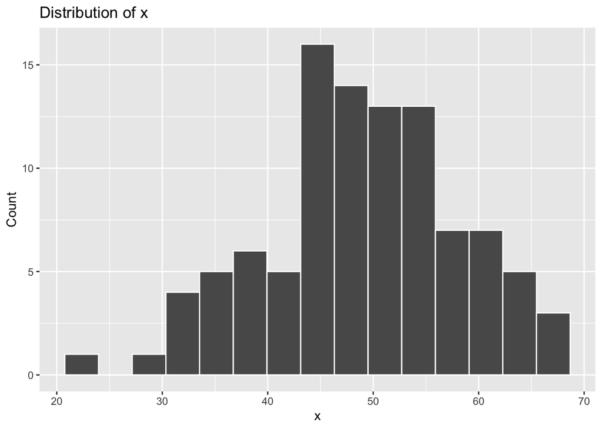

Histogram of x (EDA rubric: distribution of a key numeric variable).

```r
ggplot(data, aes(x = x)) +
  geom_histogram(bins = 15, color = "white") +
  labs(
    title = "Distribution of x",
    x = "x",
    y = "Count"
  )
```

**Interpretation (example):**

- Comment on the shape (e.g., roughly symmetric, skewed, etc.).
- Note any potential outliers.

You would tie this back to your research question, e.g.:

> “If we use `x` as a predictor, its roughly normal distribution is convenient for certain models.”

# 5 5. Boxplot of `y` by Group (EDA: Comparing Groups)

This visualization supports:

- Comparing distributions between groups (**EDA**).
- Showing a clear, labeled plot (**Visualization Quality**).

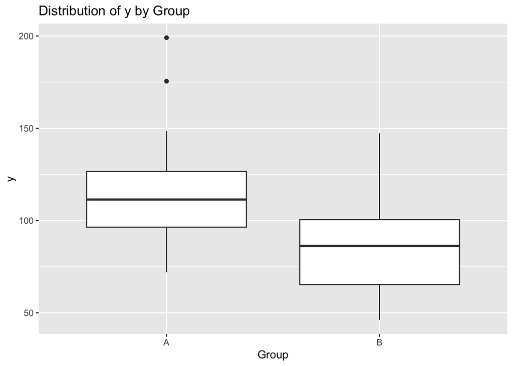

Boxplot of y by group (EDA rubric: group comparison).

```r
ggplot(data, aes(x = group, y = y)) +
  geom_boxplot() +
  labs(
    title = "Distribution of y by Group",
    x = "Group",
    y = "y"
  )
```

**Interpretation (example):**

- How do medians compare between A and B?
- Which group appears more variable?
- Are there visible outliers?

You might relate this to a question such as:

> “Does group membership (A vs B) appear to influence `y`?”

# 6 6. Scatter Plot of `x` vs `y` (EDA: Relationships)

This addresses **EDA** and prepares for **Modeling Approach** by visualizing relationships between variables.

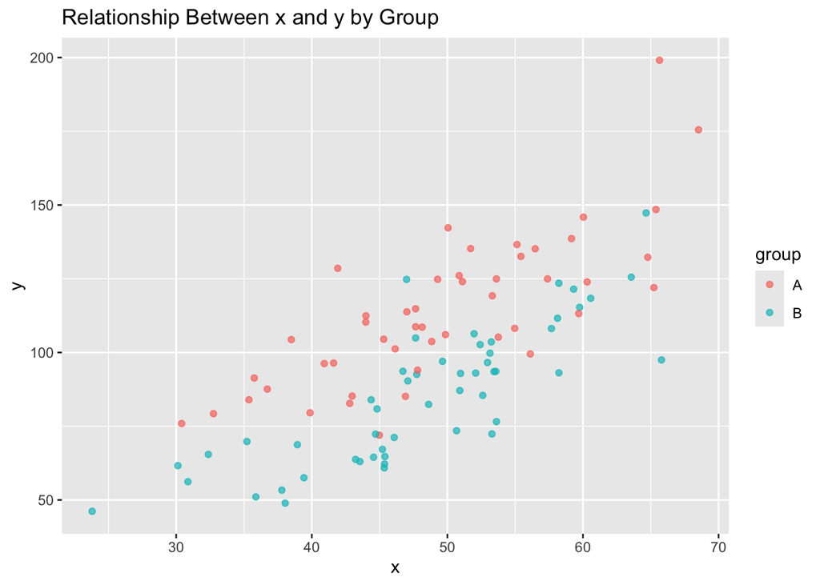

Scatter plot of y versus x, colored by group (EDA rubric: relationship between variables).

```r
ggplot(data, aes(x = x, y = y, color = group)) +
  geom_point(alpha = 0.7) +
  labs(
    title = "Relationship Between x and y by Group",
    x = "x",
    y = "y"
  )
```

**Interpretation (example):**

- Describe the direction and strength of the relationship (e.g., roughly linear and positive).
- Note whether points for groups A and B occupy different regions (interaction possibility).

This directly motivates modeling choices:

> “Because `y` increases with `x` and the relationship may differ by group, we might fit a regression model with an interaction term between `x` and `group`.”

# 7 7. Linking EDA to the Project Rubric

To fully satisfy the **EDA** and **Visualization Quality** rubric criteria in your own project:

- Include:
  - At least one distribution plot for a key variable.
  - At least one group comparison plot (if you have categorical variables).
  - At least one relationship plot (e.g., scatter plot) for important pairs of variables.
- For each figure:
  - Provide a clear title and axis labels.
  - Write 2–3 sentences interpreting the plot in the context of your research question.
  - Briefly mention how the plot informs your later modeling decisions.

Use this notebook as a pattern, but replace:

- `sample_data.csv` with your actual dataset.
- `x`, `y`, and `group` with your own variables.
- The example interpretations with your own analysis and language.